# Session 1 Setup

## How to set the working directory

`Working directory`:  
A path that sets the default location of any files  
you read into or write out of R

1. Check your current working directory

```r
getwd() # My working directory for constructing this presentation slide
```

```
[1] "C:/Users/Tek/Desktop/RWorkshop/Session 1"
```

[figure not shown]

## How to set the working directory

2. Set your working directory
1. Script: Run the following script

```r
# Replace PATH_place_holder with a directory address
setwd("PATH_place_holder")
```

2. Script: Run the following script

```r
# The following code will enable you to navigate through directories
setwd(choose.dir())
```

## Navigating Files and Directories

1. `./`

Current directory

```r
setwd("./") # Directory where this slide was generated
getwd()
```

```
[1] "C:/Users/Tek/Desktop/RWorkshop/Session 1"
```

2. `/`

Root directory

```r
setwd("/")
getwd()
```

```
[1] "C:/"
```

## Navigating Files and Directories

3. `~/`

Home directory

```r
setwd("~/")
getwd()
```

```
[1] "C:/Users/Tek/Documents"
```

4. `../`

Move to the parent directory

```r
setwd("~/../") # Note: You can start anywhere
getwd()        # Does not have to start from "~/"
```

```
[1] "C:/Users/Tek"
```

## Navigating Files and Directories

5. `/` or `\\`

Directory separator

```r
setwd("~/../Desktop") # Note: You can start anywhere
setwd("~\\..\\Desktop") # `\` requires 'escape' -> \\
getwd()
```

```
[1] "C:/Users/Tek/Desktop"
```

6. Full Path

```r
setwd("C:/Users/Tek/Desktop/RWorkshop")
setwd("C:\\Users\\Tek\\Desktop\\RWorkshop")
getwd()
```

```
[1] "C:/Users/Tek/Desktop/RWorkshop"
```

## How to set the working directory

2. Set your working directory
3. RStudio Interface

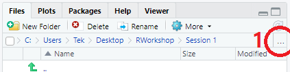

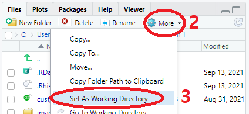

## How to set the working directory

### (Optional) How to create and modify directories in R

1. How to create and directories R
2. How to delete/rename directories in R
3. How to list directories and files in R

```r
list.dirs()
list.files()
```

## How to read and write data in R

### CSV extension

1. Reading csv file:
1. [`read.csv()`](https://www.rdocumentation.org/packages/utils/versions/3.6.2/topics/read.table)

Basic syntax

```r
# Basic syntax
read.csv(file,                 # Path and file name
         header = TRUE,        # Whether to read the header or not
         sep = ",",            # Delimiter
         quote = "\"",         # Quoting character
         dec = ".",            # Decimal point
         fill = TRUE,          # Whether to fill blacks or not
         encoding = "unknown", # Encoding of the file
         ...)                  # Additional arguments
```

NOTE: Function `read.csv()` is a wrapper of `read.table()`  
NOTE: Read [Arguments for read.csv()](https://www.rdocumentation.org/packages/utils/versions/3.6.2/topics/read.table) for additional information

## How to read and write data in R

### CSV extension

1. Reading csv file:
1. [`read.csv()`](https://www.rdocumentation.org/packages/utils/versions/3.6.2/topics/read.table)

Example

```r
# Example

# Read csv file name "csv_example" from cwd and name it df
df<-read.csv("data/csv_example.csv")
# read.csv("data/semicol.csv", header = F, sep = ";")

# `file` could be a complete URL
read.csv("url.csv")
```

## How to read and write data in R

### CSV extension

1. Reading csv file:
2. [`read_csv()`](https://readr.tidyverse.org/reference/read_delim.html)
3. [`fread()`](https://www.rdocumentation.org/packages/data.table/versions/1.14.0/topics/fread)

```r
# package_name::function_name(...)

readr::read_csv(...)
data.table::fread(...)
```

NOTE: Each package/function may have different arguments and output type

## How to read and write data in R

### CSV extension

2. Writing csv file:
1. `write.csv()`

```r
# Basic Syntax
write.csv(x,                    # Object to be exported
          file,                 # Path and File name
          row.names = TRUE,     # Whether to include row names or not
          ...)                  # Additional arguments
```

Example

```r
# Example: save df as csv file with name "write_csv"
write.csv(df, "data/write_csv.csv", row.names = F)
```